# HW_10_Predictive_Health_Analytics_Cody_York

# Import the libraries and set the working directory:

```r
library(tidyverse)
library(ggplot2)
library(MASS)
library(tree)
library(randomForest)
setwd("C:\\Users\\cy_su\\DataspellProjects\\DSCI_610_Data_Analytics_for_Health_Sciences\\Week_15")
```

# Load the dataset and do initial cleaning.

[output not shown]

```r
adult_survey <- read.csv("adult19.csv", header = TRUE)
#head(adult_survey)


adult_survey_cleaned <- subset(adult_survey, select =c(INCGRP_A,DIBEV_A,EDUC_A,AGEP_A,SEX_A,MARITAL_A,REGION,HISPALLP_A,
                                                       VISIONDF_A,BMICAT_A,HEARINGDF_A,DIFF_A,COMDIFF_A,COGMEMDFF_A))


adult_survey_cleaned$DIBEV_A_F[adult_survey_cleaned$DIBEV_A == 1] <- 0
adult_survey_cleaned$DIBEV_A_F[adult_survey_cleaned$DIBEV_A == 2] <- 1
adult_survey_cleaned$DIBEV_A_F <- factor(adult_survey_cleaned$DIBEV_A_F)

head(adult_survey_cleaned)
```

|  | INCGRP_A | DIBEV_A | EDUC_A | AGEP_A | SEX_A | MARITAL_A | REGION | HISPALLP_A | VISIONDF_A | BMICAT_A | HEARINGDF_A | DIFF_A | COMDIFF_A | COGMEMDFF_A | DIBEV_A_F |
| --- | --- | --- | --- | --- | --- | --- | --- | --- | --- | --- | --- | --- | --- | --- | --- |
| 1 | 3 | 2 | 7 | 97 | 1 | 1 | 3 | 3 | 1 | 3 | 1 | 1 | 1 | 1 | 1 |
| 2 | 3 | 2 | 6 | 28 | 2 | 1 | 3 | 2 | 1 | 2 | 1 | 1 | 1 | 1 | 1 |
| 3 | 3 | 2 | 5 | 72 | 1 | 1 | 3 | 2 | 1 | 3 | 1 | 1 | 1 | 2 | 1 |
| 4 | 5 | 2 | 7 | 60 | 1 | 1 | 3 | 1 | 2 | 4 | 1 | 1 | 1 | 1 | 1 |
| 5 | 1 | 1 | 5 | 60 | 1 | 1 | 3 | 2 | 1 | 4 | 1 | 2 | 1 | 2 | 0 |
| 6 | 2 | 1 | 5 | 78 | 1 | 1 | 3 | 3 | 1 | 4 | 2 | 2 | 1 | 2 | 0 |

# Create a train / test split for the 3 predictions

```r
set.seed(123)

train <- sample(31997, 21997)

predict_income_group <- subset(adult_survey_cleaned, select =c(INCGRP_A,AGEP_A,SEX_A,MARITAL_A,REGION,HISPALLP_A))

predict_diabetes <- subset(adult_survey_cleaned, select =c(DIBEV_A_F,AGEP_A,SEX_A,MARITAL_A,REGION,HISPALLP_A,
                                                   VISIONDF_A,BMICAT_A,HEARINGDF_A,DIFF_A,COMDIFF_A,COGMEMDFF_A))

predict_education <- subset(adult_survey_cleaned, select =c(EDUC_A,AGEP_A,SEX_A,MARITAL_A,REGION,HISPALLP_A,
                                                    VISIONDF_A,BMICAT_A,HEARINGDF_A,DIFF_A,COMDIFF_A,COGMEMDFF_A))

predict_income_group.train <- predict_income_group[train,]
predict_income_group.test <- predict_income_group[-train,]

predict_diabetes.train <- predict_diabetes[train,]
predict_diabetes.test <- predict_diabetes[-train,]
predict_diabetes.test[is.na(predict_diabetes.test)] <- 0

predict_education.train <- predict_education[train,]
predict_education.test <- predict_education[-train,]
```

# Fit a regression model against the 3 predictions and then determine the error for each

```r
lm.income.tr <- lm(INCGRP_A ~ AGEP_A + SEX_A + MARITAL_A + REGION + HISPALLP_A, data=predict_income_group.train)
income_test_error <- mean((predict_income_group.test$INCGRP_A - predict(lm.income.tr,predict_income_group.test))^2)
paste("The value of the income test error is:", income_test_error)
```

```
[1] "The value of the income test error is: 2.23695911703625"
```

```
The value of the income test error is: 2.23695911703625
```

# Create a regression tree for the quantitative value

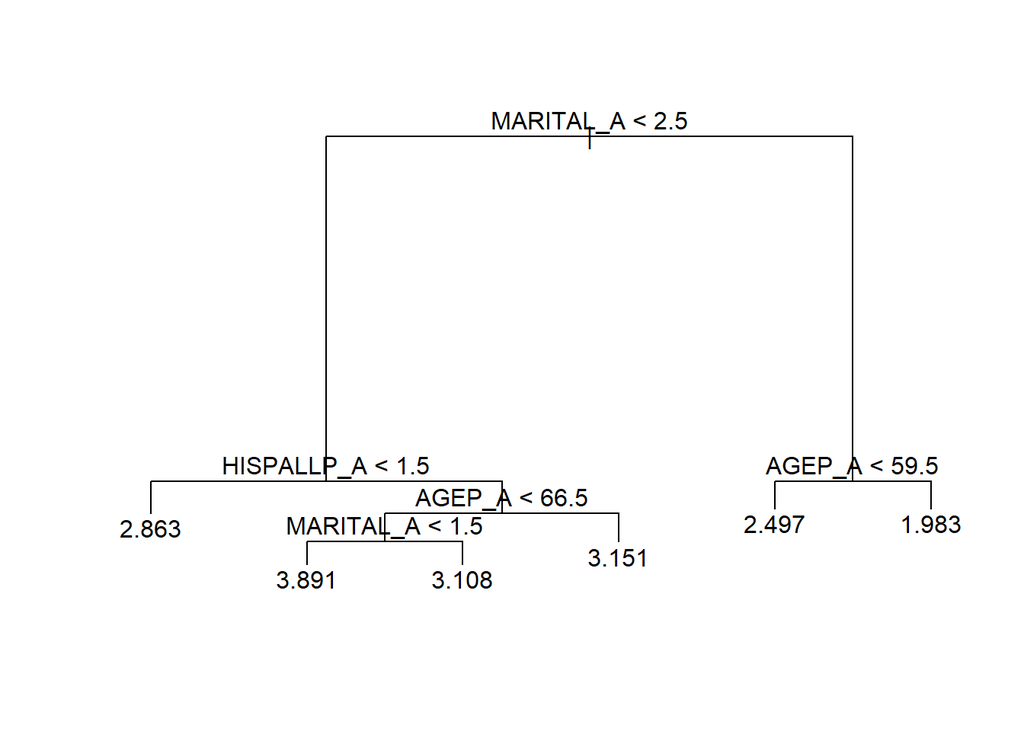

```r
tree.income <- tree(INCGRP_A ~ AGEP_A + SEX_A + MARITAL_A + REGION + HISPALLP_A, data=predict_income_group.train)
plot(tree.income)
text(tree.income, pretty =0)
```

```r
yhat <- predict(tree.income, newdata = predict_income_group.test)
income_tree_test_error <- mean((yhat-predict_income_group.test$INCGRP_A)^2)
paste("The error from the tree regression of the income group is: ", income_tree_test_error)
```

```
[1] "The error from the tree regression of the income group is:  2.03794120723649"
```

```
The error from the tree regression of the income group is:  2.03794120723649
```

```r
paste("This new model is more accurate by:", income_test_error - income_tree_test_error)
```

```
[1] "This new model is more accurate by: 0.199017909799755"
```

```
This new model is more accurate by: 0.199017909799755
```

# Create a random forest model for the quantitative value

```r
rf.income <- randomForest(INCGRP_A ~ AGEP_A + SEX_A + MARITAL_A + REGION + HISPALLP_A, data=predict_income_group.train)
rf.income
```

```
Call:
 randomForest(formula = INCGRP_A ~ AGEP_A + SEX_A + MARITAL_A +      REGION + HISPALLP_A, data = predict_income_group.train)
               Type of random forest: regression
                     Number of trees: 500
No. of variables tried at each split: 1

          Mean of squared residuals: 1.973455
                    % Var explained: 21.36
```

```r
yhat.rf.income <- predict(rf.income, newdata=predict_income_group.test)
income_forest_test_error <-mean((yhat.rf.income -predict_income_group.test$INCGRP_A)^2)
paste("The error from the forest regression of the income group is: ", income_forest_test_error)
```

```
[1] "The error from the forest regression of the income group is:  1.9976900208555"
```

```
The error from the forest regression of the income group is:  1.9976900208555
```

```r
paste("This new model is more accurate than the tree model by:",  income_tree_test_error - income_forest_test_error)
```

```
[1] "This new model is more accurate than the tree model by: 0.0402511863809907"
```

```
This new model is more accurate than the tree model by: 0.0402511863809907
```

```r
paste("This new model is more accurate than the regreession model by:", income_test_error - income_forest_test_error)
```

```
[1] "This new model is more accurate than the regreession model by: 0.239269096180746"
```

```
This new model is more accurate than the regreession model by: 0.239269096180746
```

# Create a logistic regression model for the diabetes prediction

```r
fit <- glm(DIBEV_A_F ~ AGEP_A + SEX_A + MARITAL_A + REGION + HISPALLP_A + VISIONDF_A + BMICAT_A + HEARINGDF_A + DIFF_A
                            + COMDIFF_A + COGMEMDFF_A, family = binomial, data = predict_diabetes.train)
summary(fit)
```

```
Call:
glm(formula = DIBEV_A_F ~ AGEP_A + SEX_A + MARITAL_A + REGION +
    HISPALLP_A + VISIONDF_A + BMICAT_A + HEARINGDF_A + DIFF_A +
    COMDIFF_A + COGMEMDFF_A, family = binomial, data = predict_diabetes.train)

Deviance Residuals:
    Min       1Q   Median       3Q      Max
-2.9635   0.2465   0.3502   0.4919   2.8420

Coefficients:
             Estimate Std. Error z value Pr(>|z|)
(Intercept)  5.855822   0.166035  35.269  < 2e-16 ***
AGEP_A      -0.036040   0.001502 -23.988  < 2e-16 ***
SEX_A        0.355106   0.047029   7.551 4.33e-14 ***
MARITAL_A   -0.016005   0.017191  -0.931 0.351841
REGION      -0.057970   0.022886  -2.533 0.011310 *
HISPALLP_A  -0.101996   0.025145  -4.056 4.98e-05 ***
VISIONDF_A  -0.142940   0.042692  -3.348 0.000814 ***
BMICAT_A    -0.221532   0.015269 -14.509  < 2e-16 ***
HEARINGDF_A  0.068683   0.045366   1.514 0.130035
DIFF_A      -0.494158   0.030984 -15.949  < 2e-16 ***
COMDIFF_A   -0.053627   0.062469  -0.858 0.390642
COGMEMDFF_A -0.138109   0.046164  -2.992 0.002774 **
---
Signif. codes:  0 '***' 0.001 '**' 0.01 '*' 0.05 '.' 0.1 ' ' 1

(Dispersion parameter for binomial family taken to be 1)

    Null deviance: 14824  on 21963  degrees of freedom
Residual deviance: 13073  on 21952  degrees of freedom
  (33 observations deleted due to missingness)
AIC: 13097

Number of Fisher Scoring iterations: 5
```

Marital Status, Hearing Difficulties and Communication Difficulties are insignificant and can be removed from the model

# Next we will fit the new training model as well as fit the model to the test dataset and create a confusion matrix.

## We will also be determining the rate of misclassification

```r
fit.1 <- glm(DIBEV_A_F ~ AGEP_A + SEX_A + REGION + HISPALLP_A + VISIONDF_A + BMICAT_A + DIFF_A + COGMEMDFF_A, family = binomial, data = predict_diabetes.train)
summary(fit.1)
```

```
Call:
glm(formula = DIBEV_A_F ~ AGEP_A + SEX_A + REGION + HISPALLP_A +
    VISIONDF_A + BMICAT_A + DIFF_A + COGMEMDFF_A, family = binomial,
    data = predict_diabetes.train)

Deviance Residuals:
    Min       1Q   Median       3Q      Max
-2.9427   0.2469   0.3502   0.4919   2.8648

Coefficients:
             Estimate Std. Error z value Pr(>|z|)
(Intercept)  5.843615   0.157786  37.035  < 2e-16 ***
AGEP_A      -0.035671   0.001476 -24.167  < 2e-16 ***
SEX_A        0.345157   0.046613   7.405 1.31e-13 ***
REGION      -0.057590   0.022874  -2.518  0.01181 *
HISPALLP_A  -0.104619   0.025088  -4.170 3.04e-05 ***
VISIONDF_A  -0.137578   0.042318  -3.251  0.00115 **
BMICAT_A    -0.221990   0.015267 -14.540  < 2e-16 ***
DIFF_A      -0.494355   0.030705 -16.100  < 2e-16 ***
COGMEMDFF_A -0.139314   0.043038  -3.237  0.00121 **
---
Signif. codes:  0 '***' 0.001 '**' 0.01 '*' 0.05 '.' 0.1 ' ' 1

(Dispersion parameter for binomial family taken to be 1)

    Null deviance: 14824  on 21963  degrees of freedom
Residual deviance: 13076  on 21955  degrees of freedom
  (33 observations deleted due to missingness)
AIC: 13094

Number of Fisher Scoring iterations: 5
```

```r
fit.1.probs <- predict(fit.1, predict_diabetes.test, type ="response")
glm.pred <- rep(0,10000)
glm.pred[fit.1.probs > .5] <- 1
glm.pred[fit.1.probs <= .5] <- 0
table(glm.pred, predict_diabetes.test$DIBEV_A_F)
```

```
glm.pred    0    1
       0   24   55
       1 1024 8897
```

```r
diabetes_glm_model_rate_of_misclassification <- 1-mean(glm.pred==predict_diabetes.test$DIBEV_A_F)
diabetes_glm_model_rate_of_misclassification
```

```
[1] 0.1079
```

```r
paste("The rate of miscalulation for the logistic regression model is:", diabetes_glm_model_rate_of_misclassification)
```

```
[1] "The rate of miscalulation for the logistic regression model is: 0.1079"
```

```
The rate of miscalulation for the logistic regression model is: 0.1079
```

# Next we will fit the LDA to the Diabetes Model and calculate rate of misclassification

```r
lda.diabetes.fit.1 <- lda(DIBEV_A_F ~ AGEP_A + SEX_A + REGION + HISPALLP_A + VISIONDF_A + BMICAT_A + DIFF_A + COGMEMDFF_A, data=predict_diabetes.train)
diabetes.test <- predict_diabetes.test$DIBEV_A_F

lda.diabetes.pred <- predict(lda.diabetes.fit.1 , predict_diabetes.test)

lda.diabetes.class <- lda.diabetes.pred$class

table(lda.diabetes.class, diabetes.test)
```

```
                  diabetes.test
lda.diabetes.class    0    1
                 0   78  160
                 1  970 8792
```

```r
diabetes_lda_model_rate_of_misclassification <- 1 - mean(lda.diabetes.class == diabetes.test)

paste("The rate of miscalulation for the discriminant regression model for diabetes is:", diabetes_lda_model_rate_of_misclassification)
```

```
[1] "The rate of miscalulation for the discriminant regression model for diabetes is: 0.113"
```

```
The rate of miscalulation for the discriminant regression model for diabetes is: 0.113
```

```r
paste("This new model is less accurate than the logistic model by:",   abs(diabetes_glm_model_rate_of_misclassification - diabetes_lda_model_rate_of_misclassification))
```

```
[1] "This new model is less accurate than the logistic model by: 0.00509999999999999"
```

```
This new model is less accurate than the logistic model by: 0.00509999999999999
```

# Next we will run the diabetes prediction data through the classification tree model and determine the rate of misclassification

```r
tree.diabetes <- tree(as.factor(DIBEV_A_F)~AGEP_A + SEX_A + REGION + HISPALLP_A + VISIONDF_A + BMICAT_A + DIFF_A + COGMEMDFF_A,predict_diabetes.train)

tree.diabetes.pred <- predict(tree.diabetes, predict_diabetes.test, type = "class")

table(tree.diabetes.pred, as.factor(predict_diabetes.test$DIBEV_A_F))
```

```
tree.diabetes.pred    0    1
                 0    0    0
                 1 1048 8952
```

```r
diabetes_tree_model_rate_of_misclassification <- 1 - mean(tree.diabetes.pred == as.factor(predict_diabetes.test$DIBEV_A_F))

paste("The rate of miscalulation for the tree regression model is:", diabetes_tree_model_rate_of_misclassification)
```

```
[1] "The rate of miscalulation for the tree regression model is: 0.1048"
```

```
The rate of miscalulation for the tree regression model is: 0.1048
```

```r
paste("This new model is more accurate than the discriminant regression model by:", diabetes_lda_model_rate_of_misclassification - diabetes_tree_model_rate_of_misclassification)
```

```
[1] "This new model is more accurate than the discriminant regression model by: 0.00819999999999999"
```

```
This new model is more accurate than the discriminant regression model by: 0.00819999999999999
```

```r
paste("This new model is more accurate than the logistic model by:",   diabetes_glm_model_rate_of_misclassification - diabetes_tree_model_rate_of_misclassification)
```

```
[1] "This new model is more accurate than the logistic model by: 0.00309999999999999"
```

```
This new model is more accurate than the logistic model by: 0.00309999999999999
```

# I will now try to improve the diabetes tree model performance by creating a larger tree and pruning it

```r
set.seed(567)
cv.diabetes <- cv.tree(tree.diabetes,FUN=prune.misclass)
names(cv.diabetes)
```

```
[1] "size"   "dev"    "k"      "method"
```

```
size

dev

k

method
```

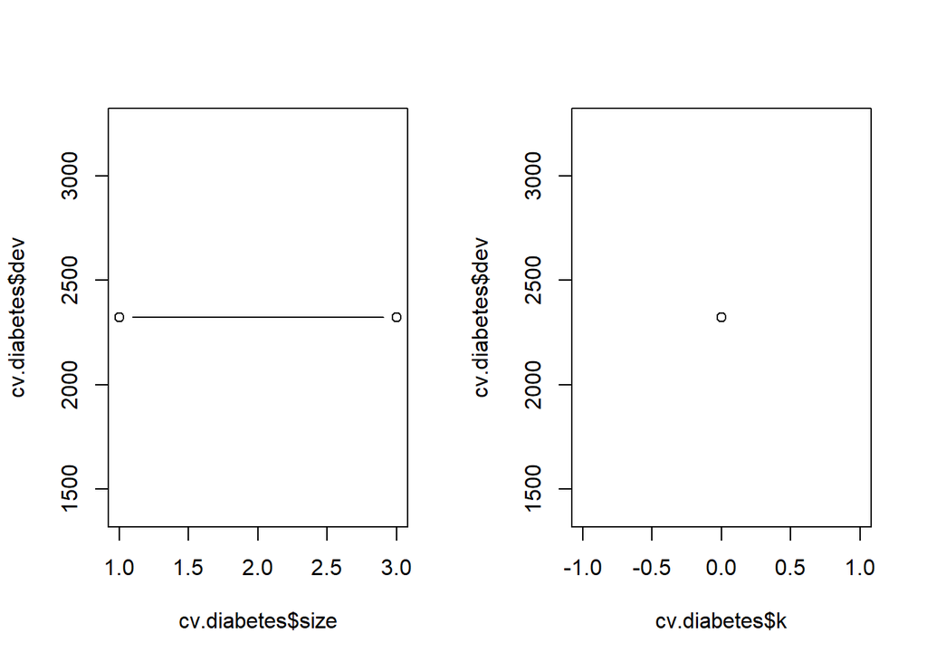

```r
par(mfrow = c(1,2))
plot(cv.diabetes$size, cv.diabetes$dev, type="b")
plot(cv.diabetes$k, cv.diabetes$dev, type="b")
```

```r
prune.diabetes <- prune.misclass(tree.diabetes, best = 4)
plot(prune.diabetes)
text(prune.diabetes, pretty = 0)

pruned.tree.diabetes.pred <- predict(prune.diabetes, predict_diabetes.test, type="class")
table(pruned.tree.diabetes.pred, as.factor(predict_diabetes.test$DIBEV_A_F))
```

```
pruned.tree.diabetes.pred    0    1
                        0    0    0
                        1 1048 8952
```

```r
diabetes_pruned_tree_model_rate_of_misclassification <- 1 - mean(pruned.tree.diabetes.pred == as.factor(predict_diabetes.test$DIBEV_A_F))

paste("The rate of miscalulation for the tree regression model is:", diabetes_pruned_tree_model_rate_of_misclassification)
```

```
[1] "The rate of miscalulation for the tree regression model is: 0.1048"
```

```
The rate of miscalulation for the tree regression model is: 0.1048
```

```r
paste("This new model is more accurate than the discriminant regression model by:", diabetes_lda_model_rate_of_misclassification - diabetes_pruned_tree_model_rate_of_misclassification)
```

```
[1] "This new model is more accurate than the discriminant regression model by: 0.00819999999999999"
```

```
This new model is more accurate than the discriminant regression model by: 0.00819999999999999
```

```r
paste("This new model is more accurate than the logistic model by:",   diabetes_glm_model_rate_of_misclassification - diabetes_pruned_tree_model_rate_of_misclassification)
```

```
[1] "This new model is more accurate than the logistic model by: 0.00309999999999999"
```

```
This new model is more accurate than the logistic model by: 0.00309999999999999
```

[output not shown]

[output not shown]

[figure not shown]

```r
paste("This new model is more accurate than the other tree model by:",   diabetes_tree_model_rate_of_misclassification - diabetes_pruned_tree_model_rate_of_misclassification)
```

# Next I will create a random forest classification for the diabetes prediction and check the rate of misclassification

```r
set.seed(890)

rf.diabetes <- randomForest(DIBEV_A_F ~ AGEP_A + SEX_A + REGION + HISPALLP_A + VISIONDF_A + BMICAT_A + DIFF_A + COGMEMDFF_A, data=predict_diabetes.test, mtry=3, importance=TRUE)
rf.diabetes
```

```
Call:
 randomForest(formula = DIBEV_A_F ~ AGEP_A + SEX_A + REGION +      HISPALLP_A + VISIONDF_A + BMICAT_A + DIFF_A + COGMEMDFF_A,      data = predict_diabetes.test, mtry = 3, importance = TRUE)
               Type of random forest: classification
                     Number of trees: 500
No. of variables tried at each split: 3

        OOB estimate of  error rate: 11%
Confusion matrix:
    0    1 class.error
0  84  964  0.91984733
1 136 8816  0.01519214
```

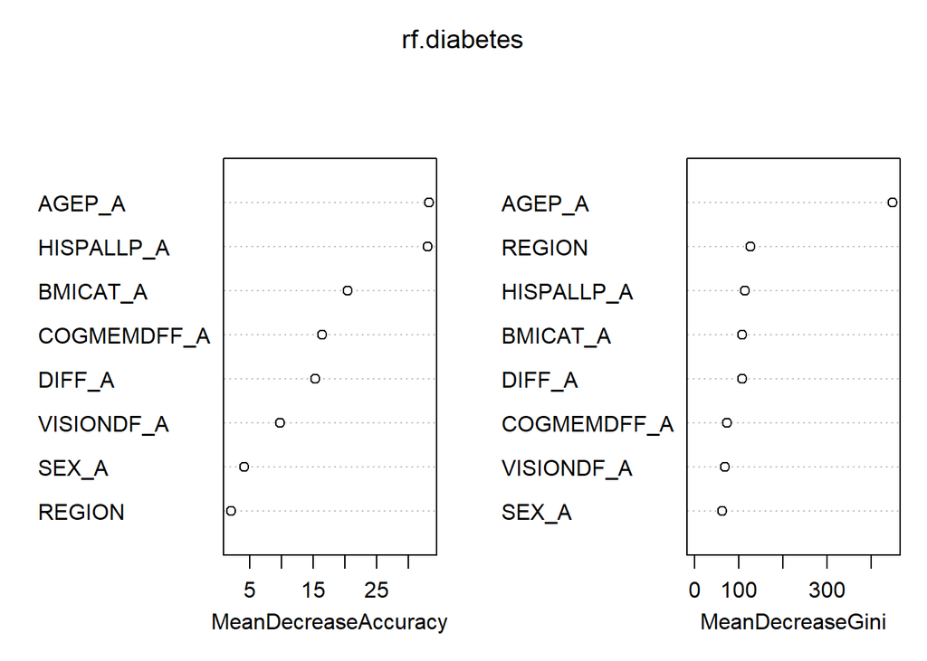

```r
varImpPlot(rf.diabetes)
```

# I will now create some models to predict the amount of education each individual has.

## This first model will be using the LDA model

```r
lda.education.fit.1 <- lda(EDUC_A ~ AGEP_A + SEX_A + MARITAL_A + REGION + HISPALLP_A + VISIONDF_A + BMICAT_A + HEARINGDF_A + DIFF_A + COMDIFF_A + COGMEMDFF_A, data=predict_education.train)
education.test <- predict_education.test$EDUC_A

lda.education.pred <- predict(lda.education.fit.1 , predict_education.test)

lda.education.class <- lda.education.pred$class

table(lda.education.class, education.test)
```

```
                   education.test
lda.education.class    0    1    2    3    4    5    6    7    8    9   10   11
                 0     4   22    3    3   31   10    3    6   11    7    1    1
                 1     2   28    0    5   24   15    4    7    8    4    0    0
                 2     0    0    0    0    0    0    0    0    0    0    0    0
                 3     0    0    0    0    0    0    0    0    0    0    0    0
                 4    19  495   76  140 1336  872  217  466  954  450   66  101
                 5     1   20    8    8   65   52    9   14   43   15    0    2
                 6     0    0    0    0    0    0    0    0    0    0    0    0
                 7     0    0    0    0    0    0    0    0    0    0    0    0
                 8     5  174   41   76  861  647  130  380 1205  553   80  112
                 9     0    0    0    0    0    0    0    0    0    0    0    0
                 10    0    0    0    0    0    0    0    0    0    0    0    0
                 11    0    0    0    0    0    0    0    0    0    0    0    0
                 97    0    4    2    0   16    3    0    3   16    1    0    1
```

[output cut: 17 more lines]

```r
education_lda_model_rate_of_misclassification <- 1 - mean(lda.education.class == education.test)

paste("The rate of miscalulation for the discriminant regression model for education is:", education_lda_model_rate_of_misclassification)
```

```
[1] "The rate of miscalulation for the discriminant regression model for education is: 0.7373"
```

```
The rate of miscalulation for the discriminant regression model for education is: 0.7373
```

# Next I will construct a tree model for the education prediction

```r
tree.education <- tree(as.factor(EDUC_A)~AGEP_A + SEX_A + REGION + HISPALLP_A + VISIONDF_A + BMICAT_A + DIFF_A + COGMEMDFF_A, predict_education.train)

tree.education.pred <- predict(tree.education, predict_education.test, type = "class")

table(tree.education.pred, as.factor(predict_education.test$EDUC_A))
```

```
tree.education.pred    0    1    2    3    4    5    6    7    8    9   10   11
                 0     0    0    0    0    0    0    0    0    0    0    0    0
                 1     0    0    0    0    0    0    0    0    0    0    0    0
                 2     0    0    0    0    0    0    0    0    0    0    0    0
                 3     0    0    0    0    0    0    0    0    0    0    0    0
                 4    31  743  130  233 2333 1599  363  876 2237 1030  147  217
                 5     0    0    0    0    0    0    0    0    0    0    0    0
                 6     0    0    0    0    0    0    0    0    0    0    0    0
                 7     0    0    0    0    0    0    0    0    0    0    0    0
                 8     0    0    0    0    0    0    0    0    0    0    0    0
                 9     0    0    0    0    0    0    0    0    0    0    0    0
                 10    0    0    0    0    0    0    0    0    0    0    0    0
                 11    0    0    0    0    0    0    0    0    0    0    0    0
                 97    0    0    0    0    0    0    0    0    0    0    0    0
                 99    0    0    0    0    0    0    0    0    0    0    0    0
```

[output cut: 16 more lines]

```r
education_tree_model_rate_of_misclassification <- 1 - mean(tree.education.pred == as.factor(predict_education.test$EDUC_A))

paste("The rate of miscalulation for the tree regression model is:", education_tree_model_rate_of_misclassification)
```

```
[1] "The rate of miscalulation for the tree regression model is: 0.7667"
```

```
The rate of miscalulation for the tree regression model is: 0.7667
```

```r
paste("This new model is less accurate than the discriminant regression model by:", abs(education_lda_model_rate_of_misclassification - education_tree_model_rate_of_misclassification))
```

```
[1] "This new model is less accurate than the discriminant regression model by: 0.0293999999999999"
```

```
This new model is less accurate than the discriminant regression model by: 0.0293999999999999
```

# I will create a pruned tree in case it will improve model accuracy for the tree model

## Looks like the model is too small for pruning so this model will be skipped.

=== CODE IF NEEDED LATER === set.seed(135)

cv.education <- cv.tree(tree.education,FUN=prune.misclass) names(cv.education)

par(mfrow = c(1,2)) plot(cv.education$size, cv.education$dev, type=“b”) plot(cv.education$k, cv.education$dev, type=“b”)

prune.education <- prune.misclass(tree.education, best = 4) plot(prune.education) text(prune.education, pretty = 0)

pruned.tree.education.pred <- predict(prune.education, predict_education.test, type=‘class’) table(pruned.tree.education.pred, as.factor(predict_education.test$EDUC_A))

education_pruned_tree_model_rate_of_misclassification <- 1 - mean(pruned.tree.education.pred == as.factor(predict_education.test$v))

paste(‘The rate of misclassification for the tree regression model is:’, education_pruned_tree_model_rate_of_misclassification) paste(‘This new model is more accurate than the discriminant regression model by:’, education_lda_model_rate_of_misclassification - diabetes_pruned_tree_model_rate_of_misclassification) paste(‘This new model is more accurate than the other tree model by:’, education_tree_model_rate_of_misclassification - education_pruned_tree_model_rate_of_misclassification) ===END===

# Create a random forest model for education prediction and graph the model

```r
set.seed(79)

rf.education <- randomForest(EDUC_A ~ AGEP_A + SEX_A + MARITAL_A + REGION + HISPALLP_A + VISIONDF_A + BMICAT_A + HEARINGDF_A + DIFF_A + COMDIFF_A + COGMEMDFF_A, data=predict_education.test, mtry=3, importance=TRUE)
rf.education
```

```
Call:
 randomForest(formula = EDUC_A ~ AGEP_A + SEX_A + MARITAL_A +      REGION + HISPALLP_A + VISIONDF_A + BMICAT_A + HEARINGDF_A +      DIFF_A + COMDIFF_A + COGMEMDFF_A, data = predict_education.test,      mtry = 3, importance = TRUE)
               Type of random forest: regression
                     Number of trees: 500
No. of variables tried at each split: 3

          Mean of squared residuals: 60.03018
                    % Var explained: -3.31
```

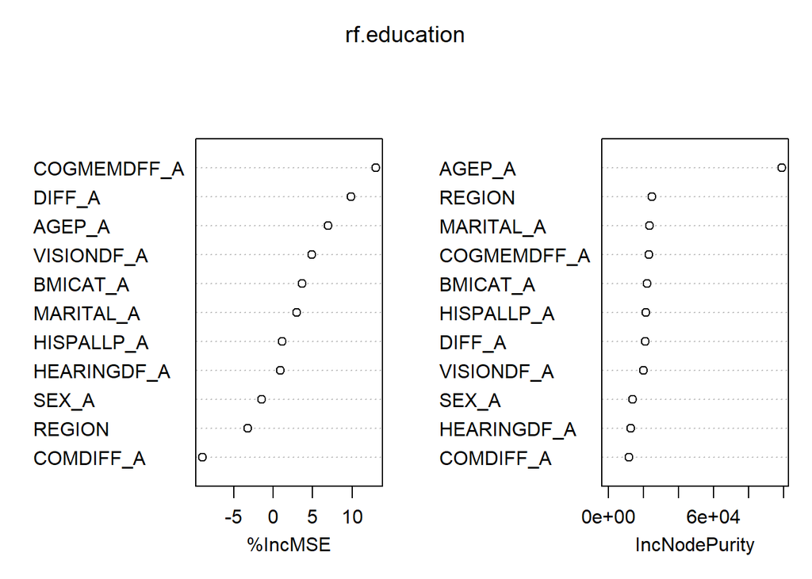

```r
varImpPlot(rf.education)
```